# Homework 3 Embeddings

## Homework 3: Embeddings

Please fill out below items

- `Your name`: Xindi Lan
- `Andrew ID`: xindilan

### Classifying newswires: a multi-class classification example

In this homework, you will continue to build on the classification model from homework 1 to classify Reuters newswires. Specifically you'll be using embeddings technique to try and enhance your model from the first homework.

### The Reuters dataset

We will be working with the *Reuters dataset*, a set of short newswires and their topics, published by Reuters in 1986. It's a very simple, widely used toy dataset for text classification. There are 46 different topics; some topics are more represented than others, but each topic has at least 10 examples in the training set.

Like IMDB and MNIST, the Reuters dataset comes packaged as part of Keras. Like with the IMDB dataset, the argument `num_words=15000` restricts the data to the 15,000 most frequently occurring words found in the data. Let's load it

```python
from keras.datasets import reuters

(train_data, train_labels), (test_data, test_labels) = reuters.load_data(num_words=15000)
```

## Tasks:

- You will be training your own embeddings for tokens in the data set.
- You will be downloading gensim's embeddings and adopting it to be used in a classifier. To receive full credit you should have completed tasks in all the sections below: `[10 points] + [1 bonus point]`

## **Deliverables**

- Jupyter notebook
- HTML file of jupyter notebook `[Goto: File-->Download as--> HTML]`

## **Specific Tasks**

- ### **Section 1: Build `Custom Embeddings` `6 points`**
  - Print the train and test data size
  - Decode the first article and print it's raw text
  - Prepare the data for modeling as required and create a `validation set`
  - Build the model with an embedding layer, and fully connected dense layers
    - Choose an embedding length size of 50
    - At-least 2 dense layers (apart from output layer), use RELU activation
    - Use appropriate output layer
    - Use dropouts
    - Use >250 epochs
  - Plot the `loss curves` and `accuracy curves` between train and validation set
  - Comment on what you're observing and record your best validation set accuracy
  - **BONUS TASK: Explore the learnt embedding +1 point**
    - Extract the embedding weights, pick one token and find words similar to it.
- ### **Section 2: Use `Glove embeddings` `4 points`**
  - Use the glove embeddings and per token.
  - Feed that as input to fully connected dense layers
    - At-least 2 dense layers (apart from output layer), use RELU activation
    - Use appropriate output layer
    - Use dropouts
    - Use >250 epochs
  - Plot the `loss curves` and `accuracy curves` between train and validation set
  - Comment on what you're observing about the tradeoffs of using pretrained embeddings vs starting them from scratch. Record your best validation set accuracy.

# Section 1: Build Custom Embeddings

```python
len(train_data)
```

```
8982
```

```python
len(test_data)
```

```
2246
```

```python
len(train_labels)
```

```
8982
```

```python
len(test_labels)
```

```
2246
```

```python
word_index = reuters.get_word_index()
reverse_word_index = dict([(value, key) for (key, value) in word_index.items()])
decoded_review = ' '.join([reverse_word_index.get(i - 3, '?') for i in train_data[0]])
```

```python
print(len(word_index))
```

```
30979
```

```python
print(decoded_review)
```

```
? ? ? said as a result of its december acquisition of space co it expects earnings per share in 1987 of 1 15 to 1 30 dlrs per share up from 70 cts in 1986 the company said pretax net should rise to nine to 10 mln dlrs from six mln dlrs in 1986 and rental operation revenues to 19 to 22 mln dlrs from …
```

```python
import numpy as np

def vectorize_sequences(sequences, dimension=15000):
    results = np.zeros((len(sequences), dimension))
    for i, sequence in enumerate(sequences):
        results[i, sequence] = 1.
    return results
```

```python
x_train = vectorize_sequences(train_data)
x_test = vectorize_sequences(test_data)
```

```python
from keras.utils.np_utils import to_categorical
y_train = to_categorical(train_labels)
y_test = to_categorical(test_labels)
```

```python
from keras import models
from keras import layers

model = models.Sequential()
model.add(layers.Embedding(15000, 50, input_length=15000))
model.add(layers.Flatten())
model.add(layers.Dense(64, activation='relu'))
model.add(layers.Dropout(0.5))
model.add(layers.Dense(64, activation='relu'))
model.add(layers.Dropout(0.5))
model.add(layers.Dense(46, activation='softmax'))
```

```python
model.compile(optimizer='rmsprop',
              loss='categorical_crossentropy',
              metrics=['accuracy'])
```

```python
history = model.fit(x_train,
                    y_train,
                    epochs=260,
                    batch_size=512,
                    validation_data=(x_test, y_test))
```

```
Train on 8982 samples, validate on 2246 samples
```

```python
history_dict = history.history
history_dict.keys()
```

```
dict_keys(['val_loss', 'val_acc', 'loss', 'acc'])
```

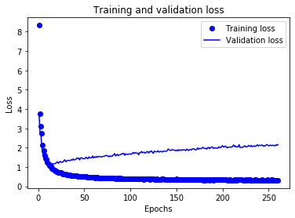

```python
import matplotlib.pyplot as plt

acc = history.history['acc']
val_acc = history.history['val_acc']
loss = history.history['loss']
val_loss = history.history['val_loss']

epochs = range(1, len(acc) + 1)

# "bo" is for "blue dot"
plt.plot(epochs, loss, 'bo', label='Training loss')
# b is for "solid blue line"
plt.plot(epochs, val_loss, 'b', label='Validation loss')
plt.title('Training and validation loss')
plt.xlabel('Epochs')
plt.ylabel('Loss')
plt.legend()

plt.show()
```

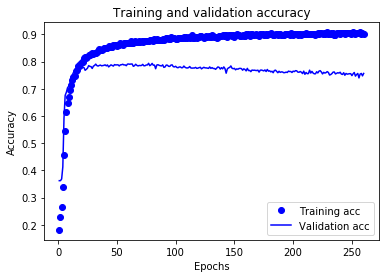

```python
plt.clf()   # clear figure
#acc_values = history_dict['binary_accuracy']
#val_acc_values = history_dict['val_binary_accuracy']

plt.plot(epochs, acc, 'bo', label='Training acc')
plt.plot(epochs, val_acc, 'b', label='Validation acc')
plt.title('Training and validation accuracy')
plt.xlabel('Epochs')
plt.ylabel('Accuracy')
plt.legend()

plt.show()
```

# Section 2: Use Glove embeddings

```python
from keras.preprocessing.text import Tokenizer
from keras.preprocessing.sequence import pad_sequences
import numpy as np
```

```python
train_text=[]
word_index = reuters.get_word_index()
reverse_word_index = dict([(value, key) for (key, value) in word_index.items()])
for txt in train_data:
    decoded_review = ' '.join([reverse_word_index.get(i - 3, '?') for i in txt])
    train_text.append(decoded_review)
```

```python
test_text=[]
for txt in test_data:
    decoded_review = ' '.join([reverse_word_index.get(i - 3, '?') for i in txt])
    test_text.append(decoded_review)
```

```python
max_words = 15000
max_sequence_length=15000
tokenizer = Tokenizer(num_words=max_words)
tokenizer.fit_on_texts(train_text)
tokenizer.fit_on_texts(test_text)
sequences1 = tokenizer.texts_to_sequences(train_text)
sequences2 = tokenizer.texts_to_sequences(test_text)
word_index = tokenizer.word_index
x_train = pad_sequences(sequences1, maxlen=max_sequence_length)
x_test = pad_sequences(sequences2, maxlen=max_sequence_length)
```

```python
from keras.utils.np_utils import to_categorical
y_train = to_categorical(train_labels)
y_test = to_categorical(test_labels)
```

```python
embeddings_index = {}
f = open('glove.6B.50d.txt')
for line in f:
    values = line.split()
    word = values[0]
    coefs = np.asarray(values[1:], dtype='float32')
    embeddings_index[word] = coefs
f.close()
```

```python
embedding_matrix = np.zeros((len(word_index) + 1, 50))
for word, i in word_index.items():
    embedding_vector = embeddings_index.get(word)
    if embedding_vector is not None:
        # words not found in embedding index will be all-zeros.
        embedding_matrix[i] = embedding_vector
```

```python
from keras.layers import Embedding

embedding_layer = Embedding(len(word_index) + 1,
                            50,
                            weights=[embedding_matrix],
                            input_length=15000,
                            trainable=False)
```

[output not shown]

```python
from keras import models
from keras import layers
sequence_input = layers.Input(shape=(15000,), dtype='int32')
embedded_sequences = embedding_layer(sequence_input)
x = layers.Flatten()(embedded_sequences)
x = layers.Dense(64, activation='relu')(x)
x = layers.Dropout(0.5)(x)
x = layers.Dense(64, activation='relu')(x)
x = layers.Dropout(0.5)(x)
preds = layers.Dense(46, activation='softmax')(x)
```

[output not shown]

```python
model = models.Model(sequence_input, preds)
model.compile(optimizer='rmsprop',
              loss='categorical_crossentropy',
              metrics=['accuracy'])
```

[output not shown]

```python
history = model.fit(x_train,
                    y_train,
                    epochs=260,
                    batch_size=512,
                    validation_data=(x_test, y_test))
```

[output not shown]

```
Train on 8982 samples, validate on 2246 samples
```

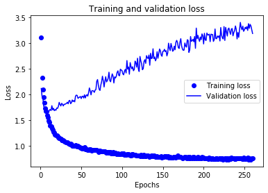

```python
import matplotlib.pyplot as plt
acc = history.history['acc']
val_acc = history.history['val_acc']
loss = history.history['loss']
val_loss = history.history['val_loss']

epochs = range(1, len(acc) + 1)

# "bo" is for "blue dot"
plt.plot(epochs, loss, 'bo', label='Training loss')
# b is for "solid blue line"
plt.plot(epochs, val_loss, 'b', label='Validation loss')
plt.title('Training and validation loss')
plt.xlabel('Epochs')
plt.ylabel('Loss')
plt.legend()

plt.show()
```

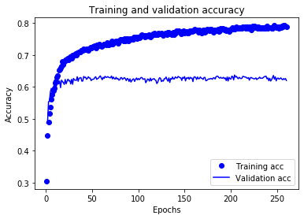

```python
plt.clf()   # clear figure
#acc_values = history_dict['binary_accuracy']
#val_acc_values = history_dict['val_binary_accuracy']

plt.plot(epochs, acc, 'bo', label='Training acc')
plt.plot(epochs, val_acc, 'b', label='Validation acc')
plt.title('Training and validation accuracy')
plt.xlabel('Epochs')
plt.ylabel('Accuracy')
plt.legend()

plt.show()
```